# UOC - Tipologia y ciclo de vida de los datos - PRA2

Limpieza y Preprocesado: Heart Attack Analysis & Prediction Dataset

Vanessa Moreno González, Manuel Ernesto Martínez Martín

1 de June 2023

# 1. Descripción del dataset

Este dataset trae dos ficheros `heart.csv` y `o2Saturation.csv` y **es importante porque proporciona información sobre factores relacionados con enfermedades cardíacas**, como edad, sexo, síntomas otros datos médicos. Ya que con el **se puede entender mejor la enfermedad y hacer un análisis para detectar cuando se puede estar en riesgo de ataque cardíaco**, sabiendo esto se pueden desarrollar modelos predictivos que tomen decisiones para ayudar a prevenir un ataque cardíaco.

El dataset es el propuesto en el enunciado de la práctica y se ha extraído de kaggle: [**Heart Attack Analysis & Prediction Dataset**](https://www.kaggle.com/datasets/rashikrahmanpritom/heart-attack-analysis-prediction-dataset)

## Contenido del dataset

Las variables que tiene el dataset son: age, sex, cp, trtbps, chol, fbs, restecg, thalachh, exng, oldpeak, slp, caa, thall y output. Siendo `output` la variable objetivo. A continuación se detallan más en profundidad.

## Análisis inicial

Verificamos la estructura del juego de datos principal y el tipo de datos con los que R ha interpretado cada variable, y si, corresponde a la descripción de las variables del fichero original:

```
## 'data.frame':    303 obs. of  14 variables:
##  $ age     : int  63 37 41 56 57 57 56 44 52 57 ...
##  $ sex     : int  1 1 0 1 0 1 0 1 1 1 ...
##  $ cp      : int  3 2 1 1 0 0 1 1 2 2 ...
##  $ trtbps  : int  145 130 130 120 120 140 140 120 172 150 ...
##  $ chol    : int  233 250 204 236 354 192 294 263 199 168 ...
##  $ fbs     : int  1 0 0 0 0 0 0 0 1 0 ...
##  $ restecg : int  0 1 0 1 1 1 0 1 1 1 ...
##  $ thalachh: int  150 187 172 178 163 148 153 173 162 174 ...
##  $ exng    : int  0 0 0 0 1 0 0 0 0 0 ...
##  $ oldpeak : num  2.3 3.5 1.4 0.8 0.6 0.4 1.3 0 0.5 1.6 ...
##  $ slp     : int  0 0 2 2 2 1 1 2 2 2 ...
##  $ caa     : int  0 0 0 0 0 0 0 0 0 0 ...
##  $ thall   : int  1 2 2 2 2 1 2 3 3 2 ...
##  $ output  : int  1 1 1 1 1 1 1 1 1 1 ...
```

Observamos que todas las variables se han cargado como númerica discreta a excepción de **oldpeak** que se ha cargado como numérica continua.

A continuación realizaremos una visión general del dataset con `glimpse()`.

```
## Rows: 303
## Columns: 14
## $ age      <int> 63, 37, 41, 56, 57, 57, 56, 44, 52, 57, 54, 48, 49, 64, 58, 5…
## $ sex      <int> 1, 1, 0, 1, 0, 1, 0, 1, 1, 1, 1, 0, 1, 1, 0, 0, 0, 0, 1, 0, 1…
## $ cp       <int> 3, 2, 1, 1, 0, 0, 1, 1, 2, 2, 0, 2, 1, 3, 3, 2, 2, 3, 0, 3, 0…
## $ trtbps   <int> 145, 130, 130, 120, 120, 140, 140, 120, 172, 150, 140, 130, 1…
## $ chol     <int> 233, 250, 204, 236, 354, 192, 294, 263, 199, 168, 239, 275, 2…
## $ fbs      <int> 1, 0, 0, 0, 0, 0, 0, 0, 1, 0, 0, 0, 0, 0, 1, 0, 0, 0, 0, 0, 0…
## $ restecg  <int> 0, 1, 0, 1, 1, 1, 0, 1, 1, 1, 1, 1, 1, 0, 0, 1, 1, 1, 1, 1, 1…
## $ thalachh <int> 150, 187, 172, 178, 163, 148, 153, 173, 162, 174, 160, 139, 1…
## $ exng     <int> 0, 0, 0, 0, 1, 0, 0, 0, 0, 0, 0, 0, 0, 1, 0, 0, 0, 0, 0, 0, 0…
## $ oldpeak  <dbl> 2.3, 3.5, 1.4, 0.8, 0.6, 0.4, 1.3, 0.0, 0.5, 1.6, 1.2, 0.2, 0…
## $ slp      <int> 0, 0, 2, 2, 2, 1, 1, 2, 2, 2, 2, 2, 2, 1, 2, 1, 2, 0, 2, 2, 1…
## $ caa      <int> 0, 0, 0, 0, 0, 0, 0, 0, 0, 0, 0, 0, 0, 0, 0, 0, 0, 0, 0, 2, 0…
## $ thall    <int> 1, 2, 2, 2, 2, 1, 2, 3, 3, 2, 2, 2, 2, 2, 2, 2, 2, 2, 2, 2, 3…
## $ output   <int> 1, 1, 1, 1, 1, 1, 1, 1, 1, 1, 1, 1, 1, 1, 1, 1, 1, 1, 1, 1, 1…
```

Y una visión en general de los valores de las variables numéricas para determinar la cantidad de valores que pueden tener, esto nos ayuda también a confirmar cuales son numéricas continuas o cuales son numéricas discretas

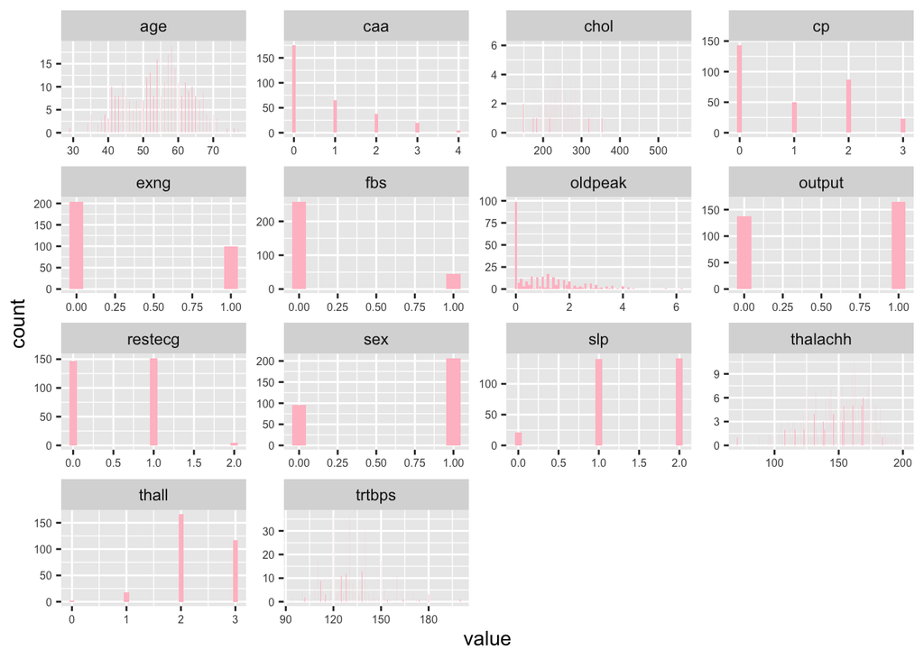

Observamos como **sex, caa, cp, fbs, restecg, exng, slp y thall** contienen un número limitado de valores únicos, por lo que, probablemente, estén representando variables categóricas. Comprobando, según la descripción oficial del dataset del punto anterior, que es cada variable y si nuestro análisis inicial es correcto, observamos que nuestra suposición es correcta, y que son variables categóricas. Por lo tanto, las convertiremos usando la función `mutate()`:

```r
# Las convertimos a factor
heartAttack <- heartAttack %>%
  mutate(across(all_of(categorical_var), factor))
```

# 2. Integración y selección de variables

Después de análisis inicial, vemos que hay realmente dos ficheros que no estan alineados en el numéro de registros y que tampoco tenemos forma de unirlos, **`heart.csv`** tiene **14 variables** y **303 registros** mientras que **`o2Saturation.csv`** con **1 variable** y **3585 registros**.

Aunque el nivel de saturación de oxigeno pueda ser importante para los ataques cardíacos, no hay manera de juntar los dos conjuntos de datos en uno solo debido a que no hay un identificador de paciente, por lo que solo usaremos `heart.csv`.

Para la selección de los datos, comprobaremos la correlación entre ellas. En el caso de las variables numéricas, realizaremos la correlación de Pearson:

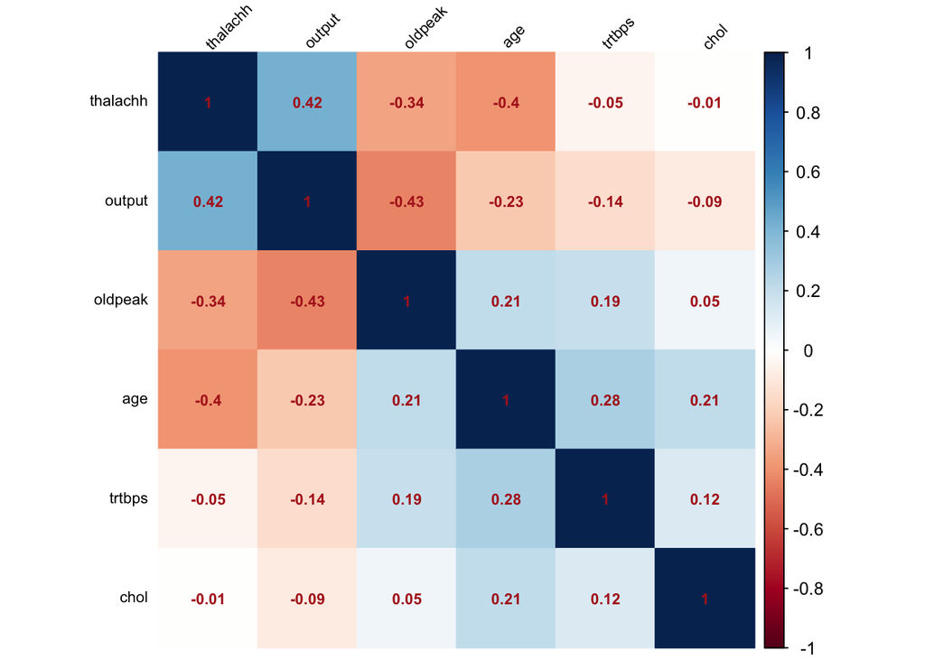

Tanto una correlación positiva como una muy negativa son interesantes para la selección de variables. Centrándonos en la fila de la variable objetivo `output` se tienen los siguientes valores:

```
##      age   trtbps     chol thalachh  oldpeak   output
##    -0.23    -0.14    -0.09     0.42    -0.43     1.00
```

Se puede tomar como referencia **0.1** como umbral para comprobar las variables que no son necesarias para el estudio, siempre en valor absoluto. En este caso para el coeficiente de correlación de pearson se tienen `age`, `trtbps`, `thalachh` y `oldpeak` como variables aptas y `chol` como poco importante.

Para las variables categóricas numéricas seria más apropiado hacer un test de `Fisher` o un `Chi-squared`.

Se va a proceder a hacer uso del test de `Fisher` con `fisher.test()`

$p = \frac{{\binom{{a+b}}{{a}} \cdot \binom{{c+d}}{{c}}}}{{\binom{{n}}{{a+c}}}}$

```r
# Creamos una lista vacía para almacenar los resultados de las pruebas de Fisher
fisher_results <- list()

# Iteramos sobre cada variable categórica
for (var in categorical_var) {
  fisher_result <- fisher.test(heartAttack[[var]], heartAttack$output)
  fisher_results[[var]] <- fisher_result
}
```

Visualizamos los resultados obtenidos del test de Fisher:

```r
print(fisher_results)
```

```
## $sex
##
##  Fisher's Exact Test for Count Data
##
## data:  heartAttack[[var]] and heartAttack$output
## p-value = 1.042e-06
## alternative hypothesis: true odds ratio is not equal to 1
## 95 percent confidence interval:
##  0.1519598 0.4783553
## sample estimates:
## odds ratio
##  0.2731136
##
##
## $caa
##
##  Fisher's Exact Test for Count Data
##
## data:  heartAttack[[var]] and heartAttack$output
## p-value < 2.2e-16
## alternative hypothesis: two.sided
##
##
## $cp
##
##  Fisher's Exact Test for Count Data
##
## data:  heartAttack[[var]] and heartAttack$output
## p-value < 2.2e-16
## alternative hypothesis: two.sided
##
##
## $fbs
##
##  Fisher's Exact Test for Count Data
##
## data:  heartAttack[[var]] and heartAttack$output
## p-value = 0.6308
## alternative hypothesis: true odds ratio is not equal to 1
## 95 percent confidence interval:
```

[output cut: 30 more lines]

```
##
##  Fisher's Exact Test for Count Data
##
## data:  heartAttack[[var]] and heartAttack$output
## p-value = 1.165e-11
## alternative hypothesis: two.sided
##
##
## $thall
##
##  Fisher's Exact Test for Count Data
##
## data:  heartAttack[[var]] and heartAttack$output
## p-value < 2.2e-16
## alternative hypothesis: two.sided
```

Se entiende entonces que las variables que tienen un *p-valor* por debajo de un nivel de significancia de **0.05** son consideradas buenas para ser escogidas para el análisis, es decir estas variables tienen un buen nivel estadístico de significancia y aportan información a los posibles modelos en las que se incluyan. De las variabels categoricas seleccionadas todas menos `fbs` tienen un p-valor por debajo de `0.05`.

Puesto que `fbs` no es una variable significativa se va a evitar su uso.

# 3. Limpieza de los datos

Volvemos a comprobar la estructura de los datos con `str()`, para verificar que los cambios realizados anteriormente se han ejecutado correctamente.

```
## 'data.frame':    303 obs. of  14 variables:
##  $ age     : int  63 37 41 56 57 57 56 44 52 57 ...
##  $ sex     : Factor w/ 2 levels "0","1": 2 2 1 2 1 2 1 2 2 2 ...
##  $ cp      : Factor w/ 4 levels "0","1","2","3": 4 3 2 2 1 1 2 2 3 3 ...
##  $ trtbps  : int  145 130 130 120 120 140 140 120 172 150 ...
##  $ chol    : int  233 250 204 236 354 192 294 263 199 168 ...
##  $ fbs     : Factor w/ 2 levels "0","1": 2 1 1 1 1 1 1 1 2 1 ...
##  $ restecg : Factor w/ 3 levels "0","1","2": 1 2 1 2 2 2 1 2 2 2 ...
##  $ thalachh: int  150 187 172 178 163 148 153 173 162 174 ...
##  $ exng    : Factor w/ 2 levels "0","1": 1 1 1 1 2 1 1 1 1 1 ...
##  $ oldpeak : num  2.3 3.5 1.4 0.8 0.6 0.4 1.3 0 0.5 1.6 ...
##  $ slp     : Factor w/ 3 levels "0","1","2": 1 1 3 3 3 2 2 3 3 3 ...
##  $ caa     : Factor w/ 5 levels "0","1","2","3",..: 1 1 1 1 1 1 1 1 1 1 ...
##  $ thall   : Factor w/ 4 levels "0","1","2","3": 2 3 3 3 3 2 3 4 4 3 ...
##  $ output  : int  1 1 1 1 1 1 1 1 1 1 ...
```

Como se puede observar las variables categóricas ya están en tipo factor.

Y ahora se va a ver un resumen general de cada una de las variables con sus valores máximos, mínimos media, mean y cuartiles utilizando la función `summary()`. Es aquí donde en los casos numéricos se pueden ver si hay valores imposibles de cumplir tanto en máximos como en mínimos.

```
##       age        sex     cp          trtbps           chol       fbs
##  Min.   :29.00   0: 96   0:143   Min.   : 94.0   Min.   :126.0   0:258
##  1st Qu.:47.50   1:207   1: 50   1st Qu.:120.0   1st Qu.:211.0   1: 45
##  Median :55.00           2: 87   Median :130.0   Median :240.0
##  Mean   :54.37           3: 23   Mean   :131.6   Mean   :246.3
##  3rd Qu.:61.00                   3rd Qu.:140.0   3rd Qu.:274.5
##  Max.   :77.00                   Max.   :200.0   Max.   :564.0
##  restecg    thalachh     exng       oldpeak     slp     caa     thall
##  0:147   Min.   : 71.0   0:204   Min.   :0.00   0: 21   0:175   0:  2
##  1:152   1st Qu.:133.5   1: 99   1st Qu.:0.00   1:140   1: 65   1: 18
##  2:  4   Median :153.0           Median :0.80   2:142   2: 38   2:166
##          Mean   :149.6           Mean   :1.04           3: 20   3:117
##          3rd Qu.:166.0           3rd Qu.:1.60           4:  5
##          Max.   :202.0           Max.   :6.20
##      output
##  Min.   :0.0000
##  1st Qu.:0.0000
##  Median :1.0000
##  Mean   :0.5446
##  3rd Qu.:1.0000
##  Max.   :1.0000
```

De la variable `caa` se tenían identificados valores de 0 a 3, **pero el valor máximos es 4**.

**Nota**: este valor de 4 en `caa` será eliminado en el apartado de los valores extremos.

## 3.1. ¿Los datos contienen ceros o elementos vacíos?

Cuando en un dataset se tienen datos nulos, hay una serie de estrategias a seguir para solucionar esto y que el juego de datos se pueda usar:

- **Eliminación de los registros**, esto a veces no es adecuado porque puede perderse mucha información que hay en otras variables que pueden ser más importantes.
- **Imputación de un valor** que puede ser: utilizar la media, la mediana, la moda, interpolación, utilización de los vecinos cercanos, u otros métodos.

### Búsqueda de ceros

Tenemos algunas variables categóricas en formato numérico en nuestro conjunto de datos. Estas variables no se pueden considerar en la búsqueda de ceros, ya que el valor `0` es una de las posibles categorías para cada una de ellas. Las variables categóricas en formato numérico que ahora son factor son `sex`, `cp`, `fbs`, `restecg`, `exng`, `slp`, `thall` y la target `output`. De las cuales son dicotomicas `sex`, `fbs`, `exng` y `output`. Además existe la variabe `caa` con tres posibles valores que indican una cantidad que puede ser 0.

También en el resumen mostrado anterior se podía ver a simple vista si alguna variable tenía 0 si este fuera su valor mínimo.

Para buscar los valores con ceros podemos usar `colSums()` y comprobando con un `=` como a continuación

```r
colSums(heartAttack %>% select(all_of(numerical_var)) == 0)
```

```
##      age   trtbps     chol thalachh  oldpeak
##        0        0        0        0       99
```

- **age**: Hay 0 pacientes con 0 años.
- **trtbps**: Hay 0 pacientes con 0 o sin presión arterial en reposo.
- **chol**: Hay 0 pacientes con 0 o sin medición de colesterol.
- **thalachh**: Hay 0 pacientes con 0 o sin ritmo cardíaco máximo alcanzado.
- **oldpeak**: Hay 99 pacientes con 0 o sin informar de la diferencia en segmento ST con electrocardiograma.

### Búsqueda de NAs

Para buscar los valores nulos podemos usar de nuevo `colSums()` pero ahora con `is.na()`

```r
colSums(is.na(heartAttack))
```

```
##      age      sex       cp   trtbps     chol      fbs  restecg thalachh
##        0        0        0        0        0        0        0        0
##     exng  oldpeak      slp      caa    thall   output
##        0        0        0        0        0        0
```

Como se puede observar **no hay valores `NA`** en este dataset, otra comprobación sería buscar valores en blanco, pero esto se haría si hubiera variables categóricas que fueran cadenas, en este caso no es necesario ya que no hay ningún valor como texto.

## 3.2. Identifica y gestiona los valores extremos

Primero en las variables numéricas vamos a comprobar cuantos valores atípicos hay de cada una

```
##      age   trtbps     chol thalachh  oldpeak
##        0        9        5        1        5
```

Como se puede observar en las variables numéricas, `age` no tiene valores atípicos.

Ahora se visualizarán los valores atípicos de las variables numéricas.

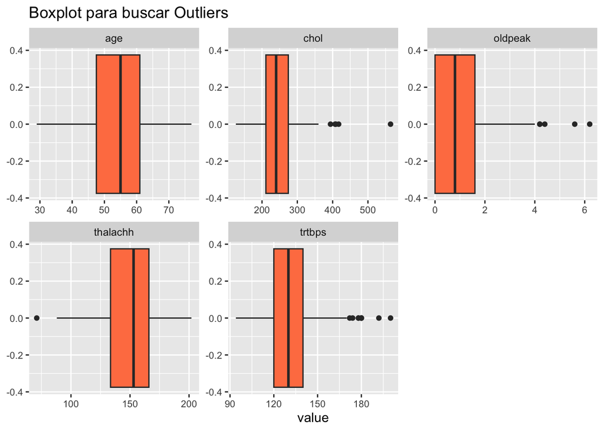

También queremos ver si se va a perder mucha información a la hora de borrar registros por ello veremos cuantos registros tenemos a tes y despues de la eliminación

```
## Valores atípicos de 'chol': 394 407 409 417 564 con un total de 5 registros
```

```
## Valores atípicos de 'oldpeak': 4.2 4.4 5.6 6.2 con un total de 5 registros
```

```
## Valores atípicos de 'thalachh': 71 con un total de 1 registros
```

```
## Valores atípicos de 'trtbps': 172 174 178 180 192 200 con un total de 9 registros
```

Se opta por eliminar los registros con valores atípicos

También aunque `caa` no se ha tenido en cuenta para comprobar los valores atípicos porque es una variable categórica, lo cierto es que según la información del dataset solo tiene 4 categorías representadas por los valores 0, 1, 2 o 3. pero existen 5 registros donde se tiene una 5ª categoría y debería ser eliminada. Como es de tipo factor se debe de usar `droplevels()` para que se elimine el nivel de dicha categoría.

```
## Cantidad de registros antes 303 y después de eliminar los valores atípicos 279
```

Realmente de 303 registros a 279 no hay mucha diferencia así que se mantiene la eliminación de outliers.

# 4. Análisis de los datos

## 4.1. Selección de los grupos de datos que se quieren analizar/comparar

Deseamos conocer la relación que existe entre las siguientes variables:

- **sex**, **cp**: Queremos conocer si existen diferencias significativas entre el tipo de dolor en el pecho que experimentan las observaciones con infarto en función del sexo.
- **age**:Queremos conocer si la media de las variables numéricas **trtbps, chol** son las mismas para los grupos de datos **age** tras realizar una discretización de esta variable.
- **output vs variables**: Queremos aproximar la relación de dependencia que existe entre la probabilidad de sufrir un infarto y las variables del dataset.

## 4.2. Comprobación de la normalidad y homogeneidad de la varianza

**sex, cp y output**: No es necesario comprobar la normalidad y homogeneidad de la varianza, ya que aplicaremos el test chi-cuadrado, que se trata de un test no parametrico.

**age**: Seleccionaremos el test a aplicar en función de la normalidad y la homogeneidad de la varianza de los grupos a comparar.

El primer paso es discretizar la variable age. Primero vamos a mostrar un histograma de la distribución de las edades

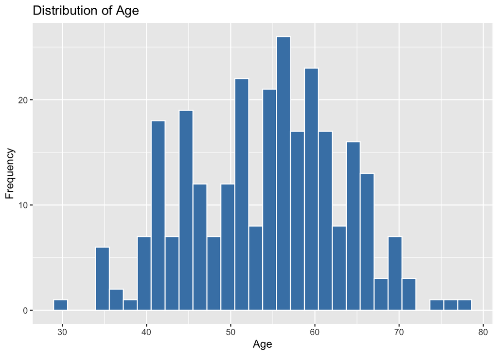

Y a continuación, discretizamos la variable en tres grupos: `Jovenes`, `Media` y `Vejez`

```r
# Calculamos los cuantiles
age_breaks <- c(0, 45, 60, 80)

# Discretizamos la variable age en grupos
heartAttack$age_discretized <-
  cut(
    heartAttack$age,
    breaks = age_breaks,
    labels = c("Jovenes", "Media", "Vejez"),
    include.lowest = TRUE
  )
```

Visualizamos el mínimo y máximo valor para age de cada grupo.

```r
# Obtener el máximo y mínimo de la variable "age_discretized" en el conjunto de datos "heartAttack"
max_min_age <- tapply(heartAttack$age, heartAttack$age_discretized, range)

# Obtener el máximo y mínimo para el grupo "tercio1"
max_jovenes <- max_min_age[["Jovenes"]][2]
min_jovenes <- max_min_age[["Jovenes"]][1]

# Obtener el máximo y mínimo para el grupo "tercio2"
max_medio <- max_min_age[["Media"]][2]
min_medio <- max_min_age[["Media"]][1]

# Obtener el máximo y mínimo para el grupo "tercio3"
max_vejez <- max_min_age[["Vejez"]][2]
min_vejez <- max_min_age[["Vejez"]][1]

cat("Jovenes -", "Mínimo:", min_jovenes,"Máximo:", max_jovenes, "\n")
```

```
## Jovenes - Mínimo: 29 Máximo: 45
```

```r
cat("Medio -", "Mínimo:", min_medio,"Máximo:", max_medio, "\n")
```

```
## Medio - Mínimo: 46 Máximo: 60
```

```r
cat("Vejez -", "Mínimo:", min_vejez,"Máximo:", max_vejez, "\n")
```

```
## Vejez - Mínimo: 61 Máximo: 77
```

Ahora comprobamos si las variables `trtbps`, `chol` presentan una distribución normal de manera visual, a través del gráfico Q-Q:

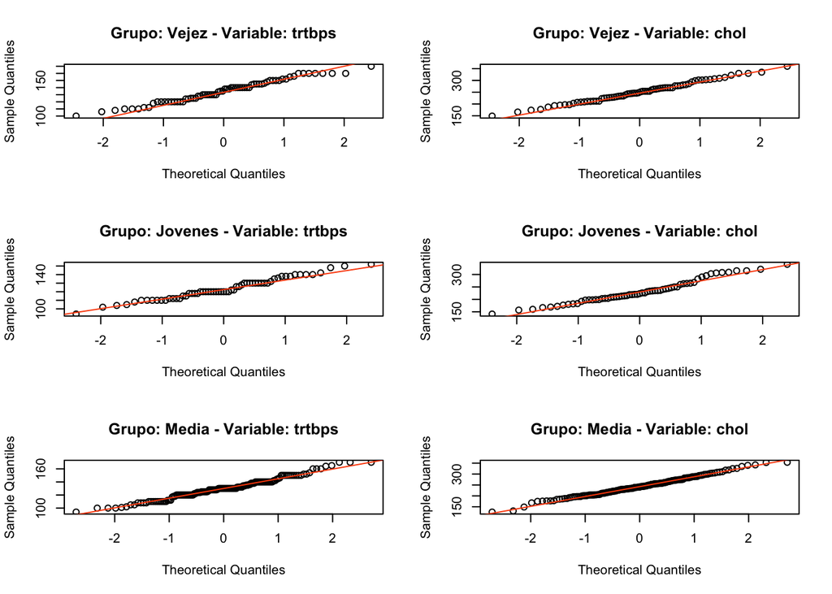

Ahora realizaremos una evaluación más cuantitativa de la distribución, mediante el test Shapiro-Wilk con `shapiro.test()`:

```r
# Comprobamos la normalidad por grupo
group_names <- unique(heartAttack$age_discretized)

for (group in group_names) {
  group_data <- subset(heartAttack, age_discretized == group)

  shapiro_test_chol <- shapiro.test(group_data$chol)
  shapiro_test_trtbps <- shapiro.test(group_data$trtbps)

  cat("Grupo:", group, "\n")
  cat("El p-value de chol es:", shapiro_test_chol$p.value, "\n")
  cat("El p-value de trtbps es:", shapiro_test_trtbps$p.value, "\n")

  if (shapiro_test_chol$p.value >= 0.05) {
    cat("La variable 'colesterol' en el grupo", group, "sigue una distribución normal.\n")
  } else {
    cat("La variable 'colesterol' en el grupo", group, "no sigue una distribución normal.\n")
  }

   if (shapiro_test_trtbps$p.value >= 0.05) {
    cat("La variable 'trtbps' en el grupo", group, "sigue una distribución normal.\n")
  } else {
    cat("La variable 'trtbps' en el grupo", group, "no sigue una distribución normal.\n")
  }
  cat("\n")
}
```

```
## Grupo: Vejez
## El p-value de chol es: 0.9713229
## El p-value de trtbps es: 0.2293937
## La variable 'colesterol' en el grupo Vejez sigue una distribución normal.
## La variable 'trtbps' en el grupo Vejez sigue una distribución normal.
##
## Grupo: Jovenes
## El p-value de chol es: 0.09457119
## El p-value de trtbps es: 0.2786165
## La variable 'colesterol' en el grupo Jovenes sigue una distribución normal.
## La variable 'trtbps' en el grupo Jovenes sigue una distribución normal.
##
## Grupo: Media
## El p-value de chol es: 0.6880372
## El p-value de trtbps es: 0.03323032
## La variable 'colesterol' en el grupo Media sigue una distribución normal.
## La variable 'trtbps' en el grupo Media no sigue una distribución normal.
```

No es necesario comprobar la homogeneidad de los datos ya que al no cumplir el criterio de normalidad, aplicaremos un test no parámetrico.

**output vs variables**: Aproximaremos la relación de dependencia entre la variable dependiente output y el resto de variables. En este caso, no es necesario que las variables presenten una distribución normal, ya que emplearemos la regresión logística, y estos supuestos no son requisitos para el modelo.

## 4.3. Aplicación de pruebas estadísticas para comparar los grupos de datos

### CHI-CUADRADO

Para analizar las diferencias entre el tipo de dolor en el pecho y el sexo en las observaciones con infarto realizaremos la prueba de chi-cuadrado.

El primer paso es seleccionar únicamente las observaciones con output 1.

```r
infarto <- subset(heartAttack, output== 1)
```

Calculamos, la frecuencia, en una tabla, con el tipo de dolor en el pecho y el sexo.

```r
tabla <- table(infarto$cp, infarto$sex)
tabla
```

```
##
##      0  1
##   0 16 21
##   1 16 24
##   2 32 31
##   3  4 11
```

Realizamos la prueba chi-cuadrado:

```r
# Prueba de chi-cuadrado
chi_square <- chisq.test(tabla)

# Imprimimos los resultados
print(chi_square)
```

```
##
##  Pearson's Chi-squared test
##
## data:  tabla
## X-squared = 3.2784, df = 3, p-value = 0.3507
```

El resultado de p-value superior a 0,05 indica que no se encuentran diferencias significativas para el tipo de dolor en el pecho y el sexo dentro de la población que sufre un infarto.

### KRUSKAL-WALLIS

Nuestra hipotesis son:

- Hipotesis nula (HO): No hay diferencias significativas de la media del valor trtbps y chol entre los diferentes grupos de edad.
- Hipotesis alternativa (H1): Hay diferencias significativas de la media del valor trtbps y chol entre los diferentes grupos de edad.

Realizamos el test de Kruskal-Wallis para la presión arterial y los diferentes grupos de edad:

```r
kruskal.test(trtbps~age_discretized, data=heartAttack)
```

```
##
##  Kruskal-Wallis rank sum test
##
## data:  trtbps by age_discretized
## Kruskal-Wallis chi-squared = 18.318, df = 2, p-value = 0.0001053
```

Realizamos el test de Kruskal-Wallis para el colesterol y los diferentes grupos de edad:

```r
kruskal.test(chol~age_discretized, data=heartAttack)
```

```
##
##  Kruskal-Wallis rank sum test
##
## data:  chol by age_discretized
## Kruskal-Wallis chi-squared = 7.0282, df = 2, p-value = 0.02977
```

Los valores de p obtenidos en ambos test, son inferiores a 0.05, por lo que podemos rechazar la hipotesis nula y concluir que el valor de colesterol y presión sanguinea varia en función del grupo de edad de las observaciones.

### REGRESIÓN LOGISTICA

Por último, aproximaremos la relación de dependencia entre la variable dependiente **output** y **el resto de variables** mediante una regresión logistica.

Dividimos los datos entre train y test.

```r
#Utilizaremos el 70% para train y el 30% para test
set.seed(23)
train_index <- sample(1:nrow(heartAttack), nrow(heartAttack) * 0.7)
train <- heartAttack[train_index, ]
test <- heartAttack[-train_index, ]
```

Ajustamos el modelo de regresión logistica.

```r
model <- glm(output ~ ., data = train, family = binomial)
```

Visualizamos el resultado del modelo:

```r
# Obtenemos los resultados del modelo
summary(model)
```

```
##
## Call:
## glm(formula = output ~ ., family = binomial, data = train)
##
## Deviance Residuals:
##     Min       1Q   Median       3Q      Max
## -2.8060  -0.2088   0.0537   0.3094   2.9412
##
## Coefficients:
##                        Estimate Std. Error z value Pr(>|z|)
## (Intercept)          -6.631e+00  5.700e+00  -1.163 0.244732
## age                   8.915e-02  8.203e-02   1.087 0.277144
## sex1                 -9.851e-01  7.650e-01  -1.288 0.197872
## cp1                   6.782e-01  7.772e-01   0.873 0.382906
## cp2                   2.537e+00  7.872e-01   3.223 0.001270 **
## cp3                   1.355e+00  1.034e+00   1.310 0.190256
## trtbps               -1.588e-02  1.888e-02  -0.841 0.400239
## chol                 -5.868e-04  6.912e-03  -0.085 0.932349
## fbs1                  8.792e-01  8.627e-01   1.019 0.308148
## restecg1              5.046e-01  5.552e-01   0.909 0.363431
## restecg2              9.951e+00  1.455e+03   0.007 0.994544
## thalachh              2.938e-02  1.904e-02   1.543 0.122816
## exng1                -4.653e-01  6.793e-01  -0.685 0.493354
## oldpeak              -1.016e+00  3.676e-01  -2.763 0.005733 **
## slp1                 -4.927e-02  1.129e+00  -0.044 0.965174
## slp2                  9.878e-01  1.172e+00   0.843 0.399228
## caa1                 -3.578e+00  7.979e-01  -4.484 7.32e-06 ***
## caa2                 -4.331e+00  1.177e+00  -3.679 0.000234 ***
## caa3                 -3.604e+00  1.379e+00  -2.612 0.008989 **
## thall1                2.663e+00  2.286e+00   1.165 0.243907
## thall2                3.175e+00  2.212e+00   1.435 0.151205
## thall3                6.361e-01  2.167e+00   0.294 0.769096
## age_discretizedMedia -1.071e+00  1.239e+00  -0.864 0.387493
## age_discretizedVejez -1.443e-01  2.078e+00  -0.069 0.944646
## ---
## Signif. codes:  0 '***' 0.001 '**' 0.01 '*' 0.05 '.' 0.1 ' ' 1
##
## (Dispersion parameter for binomial family taken to be 1)
##
##     Null deviance: 268.843  on 194  degrees of freedom
## Residual deviance:  98.763  on 171  degrees of freedom
## AIC: 146.76
##
## Number of Fisher Scoring iterations: 14
```

```r
# Ajustamos un nuevo modelo con las variables significativas
model_2 <- glm(output ~ cp + restecg + oldpeak + caa, data = train, family = binomial)

summary(model_2)
```

```
##
## Call:
## glm(formula = output ~ cp + restecg + oldpeak + caa, family = binomial,
##     data = train)
##
## Deviance Residuals:
##     Min       1Q   Median       3Q      Max
## -2.5176  -0.5029   0.2028   0.5549   2.1798
##
## Coefficients:
##              Estimate Std. Error z value Pr(>|z|)
## (Intercept)    1.2108     0.4524   2.676 0.007440 **
## cp1            1.7363     0.6200   2.800 0.005103 **
## cp2            2.5081     0.5748   4.363 1.28e-05 ***
## cp3            1.9155     0.7861   2.437 0.014818 *
## restecg1       0.1551     0.4213   0.368 0.712718
## restecg2      13.1265  1455.3977   0.009 0.992804
## oldpeak       -1.1630     0.2485  -4.681 2.86e-06 ***
## caa1          -2.6255     0.5401  -4.861 1.17e-06 ***
## caa2          -2.1105     0.6769  -3.118 0.001820 **
## caa3          -3.3078     0.9909  -3.338 0.000843 ***
## ---
## Signif. codes:  0 '***' 0.001 '**' 0.01 '*' 0.05 '.' 0.1 ' ' 1
##
## (Dispersion parameter for binomial family taken to be 1)
##
##     Null deviance: 268.84  on 194  degrees of freedom
## Residual deviance: 145.17  on 185  degrees of freedom
## AIC: 165.17
##
## Number of Fisher Scoring iterations: 14
```

Evaluamos el modelo. Predeciremos la variable output para el conjunto de test, y compararemos con los resultados reales. Visualizaremos la matriz de confusión.

```r
#Predecimos
predicted <- predict(model_2, newdata = test, type = "response") > 0.5

#realizamos la matriz de confusion
confusion_matrix <- table(predicted, test$output)

# Normalizamos la matriz de confusión
normalized_confusion_matrix <- prop.table(confusion_matrix, margin = 1)

# Visualizamos la matriz de confusión normalizada
print(normalized_confusion_matrix)
```

```
##
## predicted         0         1
##     FALSE 0.8000000 0.2000000
##     TRUE  0.2037037 0.7962963
```

Por ultimo, calcularemos la curva ROC y evaluamos el modelo con el coeficiente AUC, que indica el valor del area bajo la curva.

Visualizamos la curva:

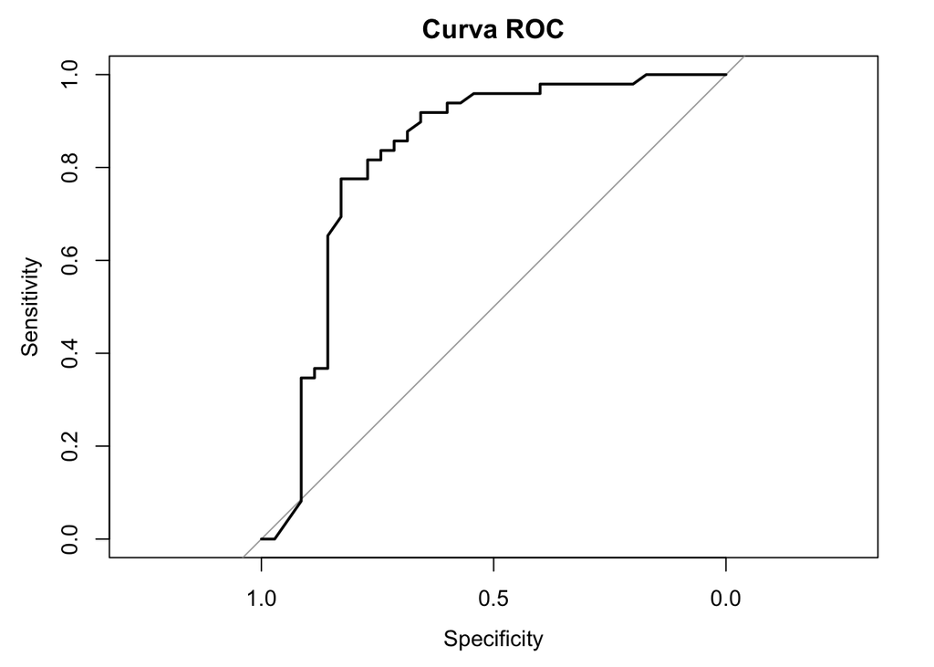

```r
plot(roc_obj, main = "Curva ROC")
```

Visualizamos el valor del coeficiente bajo la curva:

```r
auc
```

```
##
## Call:
## roc.default(response = test$output, predictor = predicted_probs)
##
## Data: predicted_probs in 35 controls (test$output 0) < 49 cases (test$output 1).
## Area under the curve: 0.8224
```

# 5. Representación de los resultados

# 6. Resolución del problema

# 7. Código

# 8. Vídeo